# Modeling and prediction for movies

## Setup

### Load packages and data

```r
library(ggplot2)
library(dplyr)
library(statsr)
```

```r
load("movies.Rdata")
```

## Part 1: Data

### Sources

The data set for this project is sourced from Rotten Tomatoes and IMDB - two of the biggest movie databases online. IMDb is the #1 movie website in the world with a combined web and mobile audience of more than 250 million unique monthly visitors. IMDb offers a searchable database of more than 185 million data items including more than 4 million movies, TV and entertainment programs and more than 6 million cast and crew members.

Rotten Tomatoes ranks movie according to the Tomatometer rating, which is based on the published opinions of hundreds of film and television critics. Tomatometer represents the percentage of professional critic reviews that are positive for a given film or television show. A movie with a 60% or higher score from the critics is considered “Fresh”. The movies with 59% or lower are considered “Rotten”.

### Generalizability and Biases

The data set for this project is sourced through APIs and comprised of 651 randomly sampled movies produced and released before 2016. Since the random sampling was used, the trends in the data can be generalized to the overall movies population. The data, however, cannot be used for determining the causation, since there was no random assignment.

There’s not much information on how IMDB and Rotten Tomatoes collect the data, so the opportunities to identify potential biases are limited. Nonetheless, one of the obvious potential biases is the voluntary response bias - the movies are ranked by those film critics and users who are willing to do it, which is, most probably, a relatively small proportion of the overall movie watchers population. Additionally, there’s a potential undercoverage bias - not all movie watchers worldwide use internet, and the internet penetration in different countries varies. These two potential biases pose a risk of some members of the movie watchers population being inadequately represented in the data set.

## Part 2: Research question

My boss has just told me that Paramount Pictures’ management has asked our team to identify what makes movies highly rated among the internet users. They hope to use the findings of this report to adjust the studio’s production and marketing strategy and estimate the future popularity of the recently released movies.

As a Data Scientist, I would like to investigate what variables in the IMDB and Rotten Tomatoes databases are associated with higher critics and audience rankings and build a predictive model.

## Part 3: Exploratory data analysis

First, let’s look at the characteristics of our data base.

```r
glimpse(movies)
```

```
## Observations: 651
## Variables: 32
## $ title            <chr> "Filly Brown", "The Dish", "Waiting for Guffm...
## $ title_type       <fctr> Feature Film, Feature Film, Feature Film, Fe...
## $ genre            <fctr> Drama, Drama, Comedy, Drama, Horror, Documen...
## $ runtime          <dbl> 80, 101, 84, 139, 90, 78, 142, 93, 88, 119, 1...
## $ mpaa_rating      <fctr> R, PG-13, R, PG, R, Unrated, PG-13, R, Unrat...
## $ studio           <fctr> Indomina Media Inc., Warner Bros. Pictures, ...
## $ thtr_rel_year    <dbl> 2013, 2001, 1996, 1993, 2004, 2009, 1986, 199...
## $ thtr_rel_month   <dbl> 4, 3, 8, 10, 9, 1, 1, 11, 9, 3, 6, 12, 1, 9, ...
## $ thtr_rel_day     <dbl> 19, 14, 21, 1, 10, 15, 1, 8, 7, 2, 19, 18, 4,...
## $ dvd_rel_year     <dbl> 2013, 2001, 2001, 2001, 2005, 2010, 2003, 200...
## $ dvd_rel_month    <dbl> 7, 8, 8, 11, 4, 4, 2, 3, 1, 8, 5, 9, 7, 2, 3,...
## $ dvd_rel_day      <dbl> 30, 28, 21, 6, 19, 20, 18, 2, 21, 14, 1, 23, ...
## $ imdb_rating      <dbl> 5.5, 7.3, 7.6, 7.2, 5.1, 7.8, 7.2, 5.5, 7.5, ...
```

[output cut: 19 more lines]

From the first look, there are no obvious problems with variables and their data types. Let’s look at the summary statistics:

```r
summary(movies)
```

```
##     title                  title_type                 genre
##  Length:651         Documentary : 55   Drama             :305
##  Class :character   Feature Film:591   Comedy            : 87
##  Mode  :character   TV Movie    :  5   Action & Adventure: 65
##                                        Mystery & Suspense: 59
##                                        Documentary       : 52
##                                        Horror            : 23
##                                        (Other)           : 60
##     runtime       mpaa_rating                               studio
##  Min.   : 39.0   G      : 19   Paramount Pictures              : 37
##  1st Qu.: 92.0   NC-17  :  2   Warner Bros. Pictures           : 30
##  Median :103.0   PG     :118   Sony Pictures Home Entertainment: 27
##  Mean   :105.8   PG-13  :133   Universal Pictures              : 23
##  3rd Qu.:115.8   R      :329   Warner Home Video               : 19
##  Max.   :267.0   Unrated: 50   (Other)                         :507
##  NA's   :1                     NA's                            :  8
##  thtr_rel_year  thtr_rel_month   thtr_rel_day    dvd_rel_year
##  Min.   :1970   Min.   : 1.00   Min.   : 1.00   Min.   :1991
##  1st Qu.:1990   1st Qu.: 4.00   1st Qu.: 7.00   1st Qu.:2001
##  Median :2000   Median : 7.00   Median :15.00   Median :2004
##  Mean   :1998   Mean   : 6.74   Mean   :14.42   Mean   :2004
##  3rd Qu.:2007   3rd Qu.:10.00   3rd Qu.:21.00   3rd Qu.:2008
##  Max.   :2014   Max.   :12.00   Max.   :31.00   Max.   :2015
##                                                 NA's   :8
##  dvd_rel_month     dvd_rel_day     imdb_rating    imdb_num_votes
##  Min.   : 1.000   Min.   : 1.00   Min.   :1.900   Min.   :   180
##  1st Qu.: 3.000   1st Qu.: 7.00   1st Qu.:5.900   1st Qu.:  4546
##  Median : 6.000   Median :15.00   Median :6.600   Median : 15116
##  Mean   : 6.333   Mean   :15.01   Mean   :6.493   Mean   : 57533
##  3rd Qu.: 9.000   3rd Qu.:23.00   3rd Qu.:7.300   3rd Qu.: 58300
##  Max.   :12.000   Max.   :31.00   Max.   :9.000   Max.   :893008
##  NA's   :8        NA's   :8
##          critics_rating critics_score    audience_rating audience_score
##  Certified Fresh:135    Min.   :  1.00   Spilled:275     Min.   :11.00
##  Fresh          :209    1st Qu.: 33.00   Upright:376     1st Qu.:46.00
##  Rotten         :307    Median : 61.00                   Median :65.00
##                         Mean   : 57.69                   Mean   :62.36
##                         3rd Qu.: 83.00                   3rd Qu.:80.00
##                         Max.   :100.00                   Max.   :97.00
##
```

[output cut: 17 more lines]

```
##  Length:651         Length:651         Length:651
##  Class :character   Class :character   Class :character
##  Mode  :character   Mode  :character   Mode  :character
##
##
##
##
##    imdb_url            rt_url
##  Length:651         Length:651
##  Class :character   Class :character
##  Mode  :character   Mode  :character
##
##
##
##
```

There aren’t many NAs, and we can safely remove them from the data set. Only 5 of 651 movies in the data set are labeled as TV movies (less than 1% of total), which doesn’t look like a true population proportion. Additionally, there’s an overlap between the “Documentary” as the type of the movie and “Documentary” as the movie genre.

```r
mov_doc <- movies %>% filter(title_type == "Documentary") %>% select(title_type, genre)

summary(mov_doc)
```

```
##         title_type                       genre
##  Documentary :55   Documentary              :49
##  Feature Film: 0   Musical & Performing Arts: 4
##  TV Movie    : 0   Comedy                   : 2
##                    Action & Adventure       : 0
##                    Animation                : 0
##                    Art House & International: 0
##                    (Other)                  : 0
```

Given these observations, it looks like the `title_type` variable is not adding much of valuable information and can be excluded.

Next, let’s look at the ratings data we have. The descriptive ranking system developed by Rotten Tomatoes is good from a marketing standpoint, but it’s not necessarily useful for our analysis, as we have numerical variables of `critics_score` and `audience_score`. Let’s look at how these scores are correlated to the IMDB score. I’ll use a function from the GGally package for a nice visual representation.

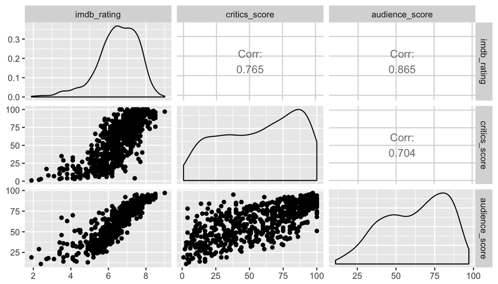

```r
mov_score <- movies %>% select(imdb_rating, critics_score, audience_score)
GGally::ggpairs(mov_score)
```

The scores are clearly collinear (correlated), and adding more than one score to the model would not add much value. We’ll use a simple average of 3 scores as a new variable `movie_score`.

Next, a movie can have several genres at once, and, to account for this, we need to split the `genre` variable into several yes/no categories. This way we’ll be able to weigh each genre separately in the model.

Finally, let’s remove the variables that clearly do not add value to the analysis (movie URLs, number of votes on IMDB) or contain too many levels (the names of the movies, directors and actors, years and days of theater/DVD releases, etc).

Let’s implement the changes discussed above:

```r
movies_database <- movies %>%
  #Removing not useful columns
  select(-c(title, title_type, thtr_rel_year, thtr_rel_month, thtr_rel_day, dvd_rel_year, dvd_rel_day, dvd_rel_month, imdb_num_votes, critics_rating, audience_rating, studio, director, actor1, actor2, actor3, actor4, actor5, imdb_url, rt_url)) %>%
  #Adding combined movie_score
  mutate(movie_score = round((imdb_rating + critics_score + audience_score)/3)) %>% select(-c(imdb_rating, critics_score, audience_score)) %>%
  #Removing NAs
  filter(!is.na(runtime)) %>%
  #Splitting the `genre` variable into separate categories
  mutate(gen_act_adv = ifelse(genre == "Action & Adventure", 1, 0), gen_anim = ifelse(genre == "Animation", 1, 0), gen_arthouse = ifelse(genre == "Art House & International", 1, 0), gen_comed = ifelse(genre == "Comedy", 1, 0), gen_docum = ifelse(genre == "Documentary", 1, 0), gen_drama = ifelse(genre == "Drama", 1, 0), gen_horror = ifelse(genre == "Horror", 1, 0), gen_musical = ifelse(genre == "Musical & Performing Arts", 1, 0), gen_mystery = ifelse(genre == "Mystery & Suspense", 1, 0), gen_sci_fi = ifelse(genre == "Science Fiction & Fantasy", 1, 0), gen_other = ifelse(genre == "Other", 1, 0)) %>%
  #Removing the `genre` variable, which is no longer needed
  select(-genre)

summary(movies_database)
```

```
##     runtime       mpaa_rating  best_pic_nom best_pic_win best_actor_win
##  Min.   : 39.0   G      : 19   no :628      no :643      no :557
##  1st Qu.: 92.0   NC-17  :  2   yes: 22      yes:  7      yes: 93
##  Median :103.0   PG     :118
##  Mean   :105.8   PG-13  :133
##  3rd Qu.:115.8   R      :329
##  Max.   :267.0   Unrated: 49
##  best_actress_win best_dir_win top200_box  movie_score     gen_act_adv
##  no :578          no :607      no :635    Min.   : 5.00   Min.   :0.0
##  yes: 72          yes: 43      yes: 15    1st Qu.:31.00   1st Qu.:0.0
##                                           Median :43.00   Median :0.0
##                                           Mean   :42.16   Mean   :0.1
##                                           3rd Qu.:56.00   3rd Qu.:0.0
##                                           Max.   :68.00   Max.   :1.0
##     gen_anim        gen_arthouse       gen_comed        gen_docum
##  Min.   :0.00000   Min.   :0.00000   Min.   :0.0000   Min.   :0.00000
##  1st Qu.:0.00000   1st Qu.:0.00000   1st Qu.:0.0000   1st Qu.:0.00000
##  Median :0.00000   Median :0.00000   Median :0.0000   Median :0.00000
##  Mean   :0.01385   Mean   :0.02154   Mean   :0.1338   Mean   :0.07846
##  3rd Qu.:0.00000   3rd Qu.:0.00000   3rd Qu.:0.0000   3rd Qu.:0.00000
##  Max.   :1.00000   Max.   :1.00000   Max.   :1.0000   Max.   :1.00000
##    gen_drama        gen_horror       gen_musical       gen_mystery
##  Min.   :0.0000   Min.   :0.00000   Min.   :0.00000   Min.   :0.00000
##  1st Qu.:0.0000   1st Qu.:0.00000   1st Qu.:0.00000   1st Qu.:0.00000
##  Median :0.0000   Median :0.00000   Median :0.00000   Median :0.00000
##  Mean   :0.4692   Mean   :0.03538   Mean   :0.01846   Mean   :0.09077
##  3rd Qu.:1.0000   3rd Qu.:0.00000   3rd Qu.:0.00000   3rd Qu.:0.00000
##  Max.   :1.0000   Max.   :1.00000   Max.   :1.00000   Max.   :1.00000
##    gen_sci_fi        gen_other
##  Min.   :0.00000   Min.   :0.00000
##  1st Qu.:0.00000   1st Qu.:0.00000
##  Median :0.00000   Median :0.00000
##  Mean   :0.01385   Mean   :0.02462
##  3rd Qu.:0.00000   3rd Qu.:0.00000
##  Max.   :1.00000   Max.   :1.00000
```

The resulting summary score distribution is left-skewed and has two prominent peaks around 37 and 63 points, with median score of 43.

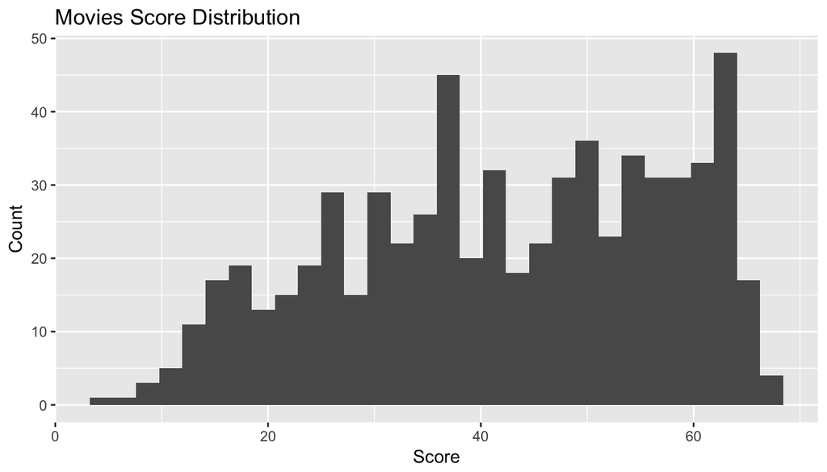

```r
ggplot(movies_database, aes(movie_score)) +
  geom_histogram() +
  ylab("Count") +
  xlab("Score") +
  ggtitle("Movies Score Distribution")
```

```r
summary(movies_database$movie_score)
```

```
##    Min. 1st Qu.  Median    Mean 3rd Qu.    Max.
##    5.00   31.00   43.00   42.16   56.00   68.00
```

## Part 4: Modeling

### Model Selection and Fitting

Since we have already excluded not relevant variables in the previous section, let’s proceed to the model building. The model should predict the consolidated movie score, and, since we already have a set of variables that seems to make sense, it would be reasonable to use a backward elimination method. The number of variables is quite high, so we’ll use the p-value-based backward elimination method, which requires fitting fewer models as compared to an R<sup>2</sup>-based method. Additionally, the p-value-based methods are more commonly used.

Let’s fit the model, using all variables that were left after we cleaned the database:

```r
mov_corr <- lm(movie_score ~ runtime + mpaa_rating + best_pic_nom + best_pic_win + best_actor_win + best_actress_win + best_dir_win + top200_box + gen_act_adv + gen_anim + gen_arthouse + gen_comed + gen_docum + gen_drama + gen_horror + gen_musical + gen_mystery + gen_sci_fi + gen_other, data = movies_database)
summary(mov_corr)
```

```
##
## Call:
## lm(formula = movie_score ~ runtime + mpaa_rating + best_pic_nom +
##     best_pic_win + best_actor_win + best_actress_win + best_dir_win +
##     top200_box + gen_act_adv + gen_anim + gen_arthouse + gen_comed +
##     gen_docum + gen_drama + gen_horror + gen_musical + gen_mystery +
##     gen_sci_fi + gen_other, data = movies_database)
##
## Residuals:
##     Min      1Q  Median      3Q     Max
## -36.176  -8.819   0.903   8.918  31.420
##
## Coefficients: (1 not defined because of singularities)
##                      Estimate Std. Error t value Pr(>|t|)
## (Intercept)          41.66002    5.50955   7.561 1.42e-13 ***
## runtime               0.09159    0.03041   3.012 0.002700 **
## mpaa_ratingNC-17     -0.06171    9.70486  -0.006 0.994929
## mpaa_ratingPG        -8.10881    3.52344  -2.301 0.021697 *
## mpaa_ratingPG-13    -13.36093    3.60517  -3.706 0.000229 ***
## mpaa_ratingR         -8.19190    3.50458  -2.337 0.019728 *
## mpaa_ratingUnrated   -2.15643    4.01477  -0.537 0.591372
## best_pic_nomyes      14.70845    3.28550   4.477 9.00e-06 ***
## best_pic_winyes      -1.93060    5.83507  -0.331 0.740860
## best_actor_winyes    -0.98015    1.52348  -0.643 0.520224
## best_actress_winyes  -0.57172    1.68661  -0.339 0.734742
## best_dir_winyes       5.85476    2.19461   2.668 0.007833 **
## top200_boxyes        10.10396    3.46268   2.918 0.003650 **
## gen_act_adv          -9.58918    3.61171  -2.655 0.008132 **
## gen_anim             -7.10670    5.82496  -1.220 0.222907
## gen_arthouse         -3.21515    4.75059  -0.677 0.498789
## gen_comed            -7.98039    3.54225  -2.253 0.024609 *
## gen_docum            13.02406    3.92404   3.319 0.000956 ***
## gen_drama             0.73272    3.31735   0.221 0.825261
## gen_horror          -10.82342    4.24389  -2.550 0.010998 *
## gen_musical           9.94466    4.91418   2.024 0.043428 *
## gen_mystery          -4.54423    3.66868  -1.239 0.215937
## gen_sci_fi           -9.41107    5.36585  -1.754 0.079940 .
## gen_other                  NA         NA      NA       NA
## ---
## Signif. codes:  0 '***' 0.001 '**' 0.01 '*' 0.05 '.' 0.1 ' ' 1
##
## Residual standard error: 12.77 on 627 degrees of freedom
## Multiple R-squared:  0.3288, Adjusted R-squared:  0.3053
## F-statistic: 13.96 on 22 and 627 DF,  p-value: < 2.2e-16
```

We see that the `gen_other` variable gives the NA coefficients in the model, which means that this variable is collinear with some other variable in the model and doesn’t give any new information. We can drop the variable, and it will not change the coefficients for other variables.

The parameter with the highest p-value is mpaa_ratingNC-17. It’s just one of the levels of the `mpaa_rating` variable, and at least 3 other levels of that variable have p-values less than 0.05. We can’t drop separate levels of a variable, so, since at least some levels of the variable are less than 0.05, we keep all levels of the variable in the model.

Aside from the `mpaa_rating` variable, `gen_drama` is the parameter with the highest p-value, let’s drop it and refit the model:

```r
mov_corr1 <- lm(movie_score ~ runtime + mpaa_rating + best_pic_nom + best_pic_win + best_actor_win + best_actress_win + best_dir_win + top200_box + gen_act_adv + gen_anim + gen_arthouse + gen_comed + gen_docum + gen_horror + gen_musical + gen_mystery + gen_sci_fi, data = movies_database)
summary(mov_corr1)
```

```
##
## Call:
## lm(formula = movie_score ~ runtime + mpaa_rating + best_pic_nom +
##     best_pic_win + best_actor_win + best_actress_win + best_dir_win +
##     top200_box + gen_act_adv + gen_anim + gen_arthouse + gen_comed +
##     gen_docum + gen_horror + gen_musical + gen_mystery + gen_sci_fi,
##     data = movies_database)
##
## Residuals:
##     Min      1Q  Median      3Q     Max
## -36.110  -8.821   0.931   8.894  31.406
##
## Coefficients:
##                      Estimate Std. Error t value Pr(>|t|)
## (Intercept)          42.35787    4.51024   9.391  < 2e-16 ***
## runtime               0.09157    0.03039   3.014 0.002686 **
## mpaa_ratingNC-17     -0.02693    9.69623  -0.003 0.997785
## mpaa_ratingPG        -8.13751    3.51837  -2.313 0.021053 *
## mpaa_ratingPG-13    -13.35275    3.60225  -3.707 0.000228 ***
## mpaa_ratingR         -8.18478    3.50178  -2.337 0.019736 *
## mpaa_ratingUnrated   -2.16971    4.01128  -0.541 0.588768
## best_pic_nomyes      14.65024    3.27243   4.477 9.00e-06 ***
## best_pic_winyes      -1.85404    5.82035  -0.319 0.750178
## best_actor_winyes    -0.97579    1.52220  -0.641 0.521732
## best_actress_winyes  -0.56124    1.68467  -0.333 0.739136
## best_dir_winyes       5.85608    2.19294   2.670 0.007772 **
## top200_boxyes        10.07699    3.45790   2.914 0.003693 **
## gen_act_adv         -10.27862    1.81559  -5.661 2.29e-08 ***
## gen_anim             -7.79482    4.91811  -1.585 0.113488
## gen_arthouse         -3.91043    3.55531  -1.100 0.271803
## gen_comed            -8.67602    1.62008  -5.355 1.20e-07 ***
## gen_docum            12.33800    2.39613   5.149 3.51e-07 ***
## gen_horror          -11.52164    2.82945  -4.072 5.26e-05 ***
## gen_musical           9.25385    3.78757   2.443 0.014831 *
## gen_mystery          -5.24650    1.82901  -2.868 0.004263 **
## gen_sci_fi          -10.09847    4.36783  -2.312 0.021100 *
## ---
## Signif. codes:  0 '***' 0.001 '**' 0.01 '*' 0.05 '.' 0.1 ' ' 1
##
## Residual standard error: 12.76 on 628 degrees of freedom
## Multiple R-squared:  0.3288, Adjusted R-squared:  0.3063
## F-statistic: 14.65 on 21 and 628 DF,  p-value: < 2.2e-16
```

Now, the `best_pic_win` has the highest p-value. Let’s remove this variable and refit the model:

```r
mov_corr2 <- lm(movie_score ~ runtime + mpaa_rating + best_pic_nom + best_actor_win + best_actress_win + best_dir_win + top200_box + gen_act_adv + gen_anim + gen_arthouse + gen_comed + gen_docum + gen_horror + gen_musical + gen_mystery + gen_sci_fi, data = movies_database)
summary(mov_corr2)
```

```
##
## Call:
## lm(formula = movie_score ~ runtime + mpaa_rating + best_pic_nom +
##     best_actor_win + best_actress_win + best_dir_win + top200_box +
##     gen_act_adv + gen_anim + gen_arthouse + gen_comed + gen_docum +
##     gen_horror + gen_musical + gen_mystery + gen_sci_fi, data = movies_database)
##
## Residuals:
##     Min      1Q  Median      3Q     Max
## -36.117  -8.883   0.979   8.908  31.393
##
## Coefficients:
##                      Estimate Std. Error t value Pr(>|t|)
## (Intercept)          42.41251    4.50376   9.417  < 2e-16 ***
## runtime               0.09111    0.03033   3.004 0.002770 **
## mpaa_ratingNC-17     -0.05568    9.68889  -0.006 0.995417
## mpaa_ratingPG        -8.13620    3.51586  -2.314 0.020981 *
## mpaa_ratingPG-13    -13.33127    3.59905  -3.704 0.000231 ***
## mpaa_ratingR         -8.17897    3.49923  -2.337 0.019733 *
## mpaa_ratingUnrated   -2.16706    4.00841  -0.541 0.588955
## best_pic_nomyes      14.19747    2.94552   4.820 1.80e-06 ***
## best_actor_winyes    -0.93664    1.51614  -0.618 0.536947
## best_actress_winyes  -0.58930    1.68116  -0.351 0.726058
## best_dir_winyes       5.65608    2.09964   2.694 0.007252 **
## top200_boxyes        10.03451    3.45286   2.906 0.003788 **
## gen_act_adv         -10.28272    1.81424  -5.668 2.20e-08 ***
## gen_anim             -7.81147    4.91432  -1.590 0.112443
## gen_arthouse         -3.92233    3.55257  -1.104 0.269979
## gen_comed            -8.70390    1.61656  -5.384 1.03e-07 ***
## gen_docum            12.32233    2.39392   5.147 3.54e-07 ***
## gen_horror          -11.53084    2.82728  -4.078 5.12e-05 ***
## gen_musical           9.25887    3.78483   2.446 0.014705 *
## gen_mystery          -5.25999    1.82722  -2.879 0.004129 **
## gen_sci_fi          -10.08565    4.36452  -2.311 0.021165 *
## ---
## Signif. codes:  0 '***' 0.001 '**' 0.01 '*' 0.05 '.' 0.1 ' ' 1
##
## Residual standard error: 12.76 on 629 degrees of freedom
## Multiple R-squared:  0.3286, Adjusted R-squared:  0.3073
## F-statistic:  15.4 on 20 and 629 DF,  p-value: < 2.2e-16
```

Next, the `best_actress_win` variable goes away:

```r
mov_corr3 <- lm(movie_score ~ runtime + mpaa_rating + best_pic_nom + best_actor_win + best_dir_win + top200_box + gen_act_adv + gen_anim + gen_arthouse + gen_comed + gen_docum + gen_horror + gen_musical + gen_mystery + gen_sci_fi, data = movies_database)
summary(mov_corr3)
```

```
##
## Call:
## lm(formula = movie_score ~ runtime + mpaa_rating + best_pic_nom +
##     best_actor_win + best_dir_win + top200_box + gen_act_adv +
##     gen_anim + gen_arthouse + gen_comed + gen_docum + gen_horror +
##     gen_musical + gen_mystery + gen_sci_fi, data = movies_database)
##
## Residuals:
##     Min      1Q  Median      3Q     Max
## -36.033  -8.993   1.047   8.951  31.363
##
## Coefficients:
##                     Estimate Std. Error t value Pr(>|t|)
## (Intercept)         42.46499    4.49813   9.441  < 2e-16 ***
## runtime              0.08994    0.03012   2.986 0.002939 **
## mpaa_ratingNC-17     0.02320    9.67953   0.002 0.998088
## mpaa_ratingPG       -8.14557    3.51331  -2.318 0.020742 *
## mpaa_ratingPG-13   -13.34294    3.59639  -3.710 0.000225 ***
## mpaa_ratingR        -8.17068    3.49671  -2.337 0.019768 *
## mpaa_ratingUnrated  -2.15465    4.00546  -0.538 0.590816
## best_pic_nomyes     14.05771    2.91638   4.820 1.80e-06 ***
## best_actor_winyes   -0.96428    1.51304  -0.637 0.524150
## best_dir_winyes      5.64372    2.09788   2.690 0.007330 **
## top200_boxyes        9.97005    3.44556   2.894 0.003940 **
## gen_act_adv        -10.20122    1.79803  -5.674 2.13e-08 ***
## gen_anim            -7.82071    4.91083  -1.593 0.111764
## gen_arthouse        -3.90362    3.54970  -1.100 0.271880
## gen_comed           -8.69455    1.61521  -5.383 1.04e-07 ***
## gen_docum           12.36617    2.38898   5.176 3.05e-07 ***
## gen_horror         -11.48160    2.82182  -4.069 5.32e-05 ***
## gen_musical          9.34053    3.77502   2.474 0.013612 *
## gen_mystery         -5.27184    1.82563  -2.888 0.004014 **
## gen_sci_fi         -10.01014    4.35617  -2.298 0.021893 *
## ---
## Signif. codes:  0 '***' 0.001 '**' 0.01 '*' 0.05 '.' 0.1 ' ' 1
##
## Residual standard error: 12.75 on 630 degrees of freedom
## Multiple R-squared:  0.3285, Adjusted R-squared:  0.3083
## F-statistic: 16.22 on 19 and 630 DF,  p-value: < 2.2e-16
```

We’re getting close! Let’s remove the `best_actor_win` variable:

```r
mov_corr4 <- lm(movie_score ~ runtime + mpaa_rating + best_pic_nom + best_dir_win + top200_box + gen_act_adv + gen_anim + gen_arthouse + gen_comed + gen_docum + gen_horror + gen_musical + gen_mystery + gen_sci_fi, data = movies_database)
summary(mov_corr4)
```

```
##
## Call:
## lm(formula = movie_score ~ runtime + mpaa_rating + best_pic_nom +
##     best_dir_win + top200_box + gen_act_adv + gen_anim + gen_arthouse +
##     gen_comed + gen_docum + gen_horror + gen_musical + gen_mystery +
##     gen_sci_fi, data = movies_database)
##
## Residuals:
##     Min      1Q  Median      3Q     Max
## -35.834  -9.257   0.988   9.004  31.407
##
## Coefficients:
##                     Estimate Std. Error t value Pr(>|t|)
## (Intercept)         42.72947    4.47684   9.545  < 2e-16 ***
## runtime              0.08629    0.02956   2.919 0.003636 **
## mpaa_ratingNC-17    -0.35849    9.65643  -0.037 0.970397
## mpaa_ratingPG       -8.21440    3.50999  -2.340 0.019579 *
## mpaa_ratingPG-13   -13.36198    3.59457  -3.717 0.000219 ***
## mpaa_ratingR        -8.17793    3.49505  -2.340 0.019602 *
## mpaa_ratingUnrated  -2.12377    4.00328  -0.531 0.595947
## best_pic_nomyes     13.88655    2.90262   4.784 2.14e-06 ***
## best_dir_winyes      5.60997    2.09622   2.676 0.007639 **
## top200_boxyes        9.93837    3.44358   2.886 0.004034 **
## gen_act_adv        -10.15657    1.79582  -5.656 2.35e-08 ***
## gen_anim            -7.85109    4.90828  -1.600 0.110197
## gen_arthouse        -3.79377    3.54384  -1.071 0.284793
## gen_comed           -8.66311    1.61370  -5.368 1.12e-07 ***
## gen_docum           12.40953    2.38689   5.199 2.71e-07 ***
## gen_horror         -11.39912    2.81753  -4.046 5.86e-05 ***
## gen_musical          9.43088    3.77058   2.501 0.012631 *
## gen_mystery         -5.37272    1.81790  -2.955 0.003239 **
## gen_sci_fi          -9.87050    4.34861  -2.270 0.023556 *
## ---
## Signif. codes:  0 '***' 0.001 '**' 0.01 '*' 0.05 '.' 0.1 ' ' 1
##
## Residual standard error: 12.74 on 631 degrees of freedom
## Multiple R-squared:  0.3281, Adjusted R-squared:  0.3089
## F-statistic: 17.12 on 18 and 631 DF,  p-value: < 2.2e-16
```

Removing the `gen_arthouse` variable and refitting once again:

```r
mov_corr5 <- lm(movie_score ~ runtime + mpaa_rating + best_pic_nom + best_dir_win + top200_box + gen_act_adv + gen_anim + gen_comed + gen_docum + gen_horror + gen_musical + gen_mystery + gen_sci_fi, data = movies_database)
summary(mov_corr5)
```

```
##
## Call:
## lm(formula = movie_score ~ runtime + mpaa_rating + best_pic_nom +
##     best_dir_win + top200_box + gen_act_adv + gen_anim + gen_comed +
##     gen_docum + gen_horror + gen_musical + gen_mystery + gen_sci_fi,
##     data = movies_database)
##
## Residuals:
##     Min      1Q  Median      3Q     Max
## -35.700  -9.179   1.075   9.019  31.454
##
## Coefficients:
##                     Estimate Std. Error t value Pr(>|t|)
## (Intercept)         42.37780    4.46529   9.490  < 2e-16 ***
## runtime              0.08810    0.02952   2.985 0.002947 **
## mpaa_ratingNC-17    -0.18779    9.65623  -0.019 0.984490
## mpaa_ratingPG       -8.19307    3.51034  -2.334 0.019909 *
## mpaa_ratingPG-13   -13.32482    3.59482  -3.707 0.000228 ***
## mpaa_ratingR        -8.19210    3.49543  -2.344 0.019404 *
## mpaa_ratingUnrated  -2.54527    3.98433  -0.639 0.523172
## best_pic_nomyes     13.95229    2.90231   4.807 1.91e-06 ***
## best_dir_winyes      5.66147    2.09591   2.701 0.007094 **
## top200_boxyes        9.95654    3.44394   2.891 0.003972 **
## gen_act_adv        -10.00913    1.79074  -5.589 3.39e-08 ***
## gen_anim            -7.66438    4.90575  -1.562 0.118712
## gen_comed           -8.50347    1.60698  -5.292 1.67e-07 ***
## gen_docum           12.83163    2.35437   5.450 7.22e-08 ***
## gen_horror         -11.16991    2.80970  -3.975 7.83e-05 ***
## gen_musical          9.64131    3.76589   2.560 0.010694 *
## gen_mystery         -5.22537    1.81289  -2.882 0.004081 **
## gen_sci_fi          -9.71429    4.34666  -2.235 0.025774 *
## ---
## Signif. codes:  0 '***' 0.001 '**' 0.01 '*' 0.05 '.' 0.1 ' ' 1
##
## Residual standard error: 12.74 on 632 degrees of freedom
## Multiple R-squared:  0.3269, Adjusted R-squared:  0.3088
## F-statistic: 18.05 on 17 and 632 DF,  p-value: < 2.2e-16
```

And the `gen_anim` one also has to go away:

```r
mov_corr6 <- lm(movie_score ~ runtime + mpaa_rating + best_pic_nom + best_dir_win + top200_box + gen_act_adv + gen_comed + gen_docum + gen_horror + gen_musical + gen_mystery + gen_sci_fi, data = movies_database)
summary(mov_corr6)
```

```
##
## Call:
## lm(formula = movie_score ~ runtime + mpaa_rating + best_pic_nom +
##     best_dir_win + top200_box + gen_act_adv + gen_comed + gen_docum +
##     gen_horror + gen_musical + gen_mystery + gen_sci_fi, data = movies_database)
##
## Residuals:
##     Min      1Q  Median      3Q     Max
## -37.192  -9.157   1.204   8.947  31.215
##
## Coefficients:
##                     Estimate Std. Error t value Pr(>|t|)
## (Intercept)         39.43917    4.05441   9.727  < 2e-16 ***
## runtime              0.09121    0.02948   3.094 0.002064 **
## mpaa_ratingNC-17     2.44000    9.51943   0.256 0.797789
## mpaa_ratingPG       -5.94752    3.20624  -1.855 0.064063 .
## mpaa_ratingPG-13   -10.87032    3.23702  -3.358 0.000832 ***
## mpaa_ratingR        -5.68665    3.10937  -1.829 0.067889 .
## mpaa_ratingUnrated  -0.19343    3.69321  -0.052 0.958247
## best_pic_nomyes     13.99137    2.90550   4.815 1.84e-06 ***
## best_dir_winyes      5.65525    2.09829   2.695 0.007222 **
## top200_boxyes       10.27308    3.44188   2.985 0.002948 **
## gen_act_adv         -9.63254    1.77646  -5.422 8.38e-08 ***
## gen_comed           -8.26275    1.60140  -5.160 3.31e-07 ***
## gen_docum           13.24130    2.34238   5.653 2.39e-08 ***
## gen_horror         -10.98688    2.81045  -3.909 0.000103 ***
## gen_musical          9.81625    3.76851   2.605 0.009408 **
## gen_mystery         -5.07197    1.81229  -2.799 0.005288 **
## gen_sci_fi          -9.25886    4.34181  -2.132 0.033351 *
## ---
## Signif. codes:  0 '***' 0.001 '**' 0.01 '*' 0.05 '.' 0.1 ' ' 1
##
## Residual standard error: 12.76 on 633 degrees of freedom
## Multiple R-squared:  0.3243, Adjusted R-squared:  0.3072
## F-statistic: 18.98 on 16 and 633 DF,  p-value: < 2.2e-16
```

Looks like this is our final model, with adjusted R<sup>2</sup> of roughly 0.31. That means that this model explains ~31% of the variability in this data set, which doesn’t look high.

### Model Diagnostics

Let’s check if our model satisfies the requirements of the Multiple Linear Regression.

1. Each numerical explanatory variable (just one in this case) should be linearly related to the response variable.

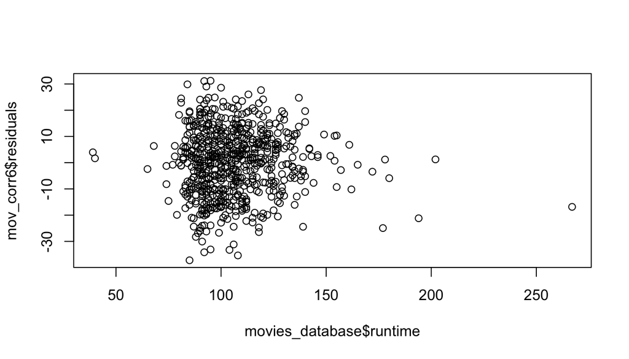

```r
plot(mov_corr6$residuals ~ movies_database$runtime)
```

The residuals seem to be randomly scattered around zero, so this condition is met.

2. Residuals should be nearly normal with mean around zero

Let’s plot a histogram of residuals and the residuals normal plot:

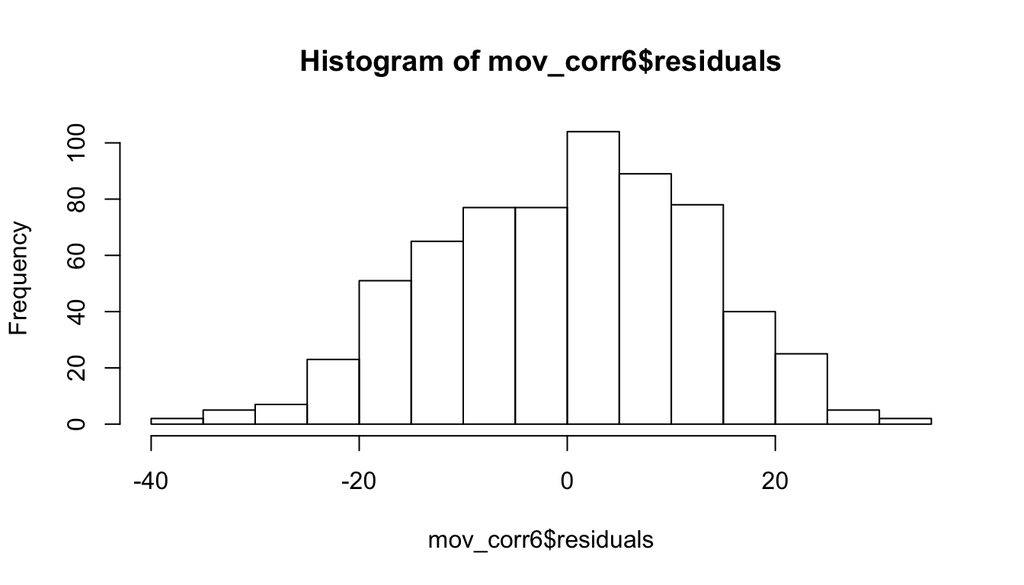

```r
hist(mov_corr6$residuals)
```

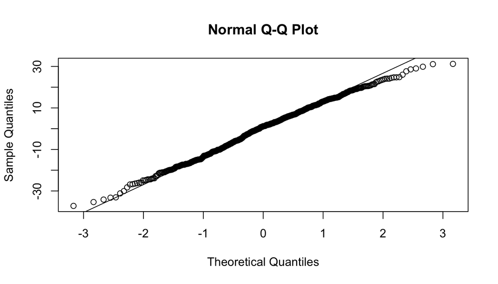

```r
qqnorm(mov_corr6$residuals)
qqline(mov_corr6$residuals)
```

The residuals are nearly normal with slight left skew. The normal residuals plot shows some diversion from normality at the tails, but overall the distribution is nearly normal, so we can consider this condition also met.

3. Residuals should be equally variable for low and high values of the predicted response variable

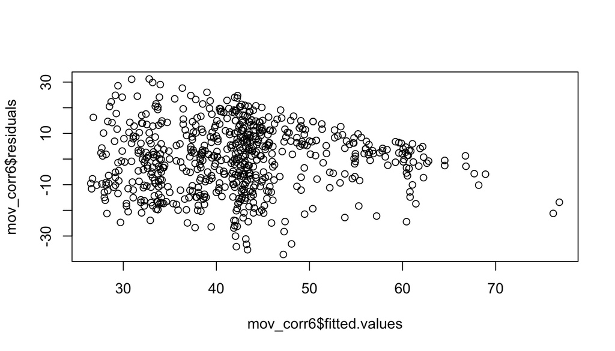

```r
plot(mov_corr6$residuals ~ mov_corr6$fitted.values)
```

This condition is not met - we can see a “fan” shape on the plot (also called heteroscedasctisity), which means that the model reqiures improvement. The most common solution to this is to transform a variable (e.g., a logarithm transformation). Also, it means that the model works better for the “narrower” part of the fan, which is observed for the higher scores.

The only variable that can be log-transformed in our final model is `runtime`. Let’s do the transformation and see if it improves the variability of the residuals:

```r
runtime2 <- log(movies_database$runtime)

mov_corr_final <- lm(movie_score ~ runtime2 + mpaa_rating + best_pic_nom + best_dir_win + top200_box + gen_act_adv + gen_comed + gen_docum + gen_horror + gen_musical + gen_mystery + gen_sci_fi, data = movies_database)

summary(mov_corr_final)
```

```
##
## Call:
## lm(formula = movie_score ~ runtime2 + mpaa_rating + best_pic_nom +
##     best_dir_win + top200_box + gen_act_adv + gen_comed + gen_docum +
##     gen_horror + gen_musical + gen_mystery + gen_sci_fi, data = movies_database)
##
## Residuals:
##     Min      1Q  Median      3Q     Max
## -37.208  -9.043   1.086   8.829  31.288
##
## Coefficients:
##                    Estimate Std. Error t value Pr(>|t|)
## (Intercept)         -1.9024    15.3237  -0.124 0.901237
## runtime2            11.0544     3.3430   3.307 0.000997 ***
## mpaa_ratingNC-17     2.1571     9.5115   0.227 0.820660
## mpaa_ratingPG       -6.4169     3.2190  -1.993 0.046640 *
## mpaa_ratingPG-13   -11.3596     3.2558  -3.489 0.000518 ***
## mpaa_ratingR        -6.1491     3.1243  -1.968 0.049488 *
## mpaa_ratingUnrated  -0.5535     3.7013  -0.150 0.881175
## best_pic_nomyes     14.1121     2.8873   4.888 1.30e-06 ***
## best_dir_winyes      5.6802     2.0889   2.719 0.006723 **
## top200_boxyes       10.2098     3.4369   2.971 0.003084 **
## gen_act_adv         -9.5770     1.7752  -5.395 9.70e-08 ***
## gen_comed           -8.1036     1.6056  -5.047 5.87e-07 ***
## gen_docum           13.7129     2.3609   5.808 1.00e-08 ***
## gen_horror         -10.7506     2.8147  -3.819 0.000147 ***
## gen_musical          9.7422     3.7651   2.588 0.009888 **
## gen_mystery         -5.0771     1.8104  -2.804 0.005195 **
## gen_sci_fi          -9.0759     4.3395  -2.091 0.036883 *
## ---
## Signif. codes:  0 '***' 0.001 '**' 0.01 '*' 0.05 '.' 0.1 ' ' 1
##
## Residual standard error: 12.74 on 633 degrees of freedom
## Multiple R-squared:  0.3257, Adjusted R-squared:  0.3086
## F-statistic: 19.11 on 16 and 633 DF,  p-value: < 2.2e-16
```

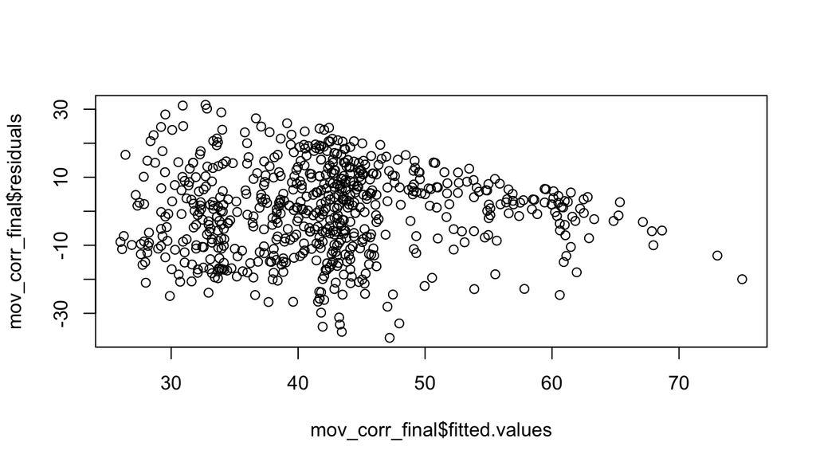

```r
plot(mov_corr_final$residuals ~ mov_corr_final$fitted.values)
```

The residuals doesn’t seem to have changed much, but the adjusted R<sup>2</sup> has improved in comparison to the non-transformed model.

4. The residuals should be independent (no time-series dependencies)

Since we have a random sample of the movies, there should be no time-series dependencies in the residuals, so this condition can be considered as met.

### Interpretation of the final model

Let’s write down our final model and interpret the coefficients:

Movie_Score = -1.9 + 11.05(log of runtime) + 0(mpaa_rating_G) + 2.15(mpaa_rating_NC-17) - 6.41(mpaa_rating_PG) - 11.35(mpaa_rating_PG_13) - 6.14(mpaa_rating_R) - 0.6(mpaa_rating_Unrated) + 14.11(best_pic_nom_yes) + 5.68(best_dir_win_yes) + 10.2(top200_box_yes) - 9.58(gen_act_adv) - 8.1(gen_comed) + 13.71(gen_docum) - 10.75(gen_horror) + 9.74(gen_musical) - 5.08(gen_mystery) - 9.08(gen_sci_fi)

According to this model, to get the highest possible score a movie should be a Documentary, have a long runtime (the longer the better), and have an MPAA rating of NC-17. The movie should also be nominated for an Oscar, and its director should be an Oscar-winner (though not necessarily for the same movie). It would also help if the movie is in the Top 200 Box Office list on BoxOfficeMojo.

## Part 5: Prediction

To test our model, I’ve picked the 2016 movie “Arrival”. I’m not good enough APIs yet, and there seems to be no “official” API for IMDB, so I just took the rankings and other movie parameters from the relevant pages:

http://www.imdb.com/title/tt2543164/?ref_=adv_li_tt

https://www.rottentomatoes.com/m/arrival_2016

The Rotten Tomatoes rankings are represented differently from what we have in our movie data set. To make them comparable, I took the Averate Ratings for critics and audience and converted them into 1 to 100 scale. The resulting parameters of the movie can be summarized below as follows. I kept only the parameters that count as predictors in the model. Also, remember that we need to log-transform the runtime.

```r
imdb_score <- 8
rotten_tomatoes_avg_critics <- 83
rotten_tomatoes_avg_audience <- 80

new_movie_score <- (imdb_score + rotten_tomatoes_avg_critics + rotten_tomatoes_avg_audience)/3

new_movie <- data.frame(gen_mystery = 1, gen_sci_fi = 1, runtime2 = log(116), mpaa_rating = "PG-13", best_pic_nom = "yes", best_dir_win = "no", top200_box = "no", gen_act_adv = 0, gen_comed = 0, gen_docum = 0, gen_horror = 0, gen_musical = 0)
```

Let’s do the prediction using the `predict` function, calculate the prediction interval with 95% confidence level and compare the predicted value to the actual movie score:

```r
new_movie_pred <- predict(mov_corr_final, new_movie, interval = "prediction", level = 0.95)

new_movie_pred
```

```
##        fit      lwr      upr
## 1 39.24518 11.89948 66.59088
```

```r
new_movie_score
```

```
## [1] 57
```

## Part 6: Conclusion

The predicted score of our model was substantially lower than the actual score, though the 95% confidence interval still captured the true score. With the adjusted R<sup>2</sup> of only ~0.31, this is probably not the best model for predicting the scores of the movies based on the characteristics of the movies we discussed above. One of the potential explanations for the low R<sup>2</sup> may be the p-value backward elimination method we used - though the results of our resulting model are statistically significant, an R<sup>2</sup>-based elimination method, though computation-intensive, could result in a higher R<sup>2</sup> and more precise movie score prediction.

Additionally, the fan-shaped residuals vs. fitted values plot showed that the model works better for the higher scores and becomes more and more uncertain as the scores go lower. Since it may be a sign of an important variable missing in the data set, a way to improve the model could be to add more variables from the IMDB and Rotten Tomatoes databased and look for additional strong predictors.

Overall, the linear regression model is not robust against outliers, which means that several super movie hits in the data set can potentially significantly skew the results. One of the ways to avoid this could be to use more sophisticated prediction methods (e.g., Decision Trees).